# Simple Simulation Example

Yuxin Zou

2018-01-10

**Last updated:** 2018-01-10

Loading the functions:

```r
library(ashr)
library(plyr)
library(mvtnorm)
library(assertthat)
source('~/Documents/GitHub/mashr-zou/R/compute_covs.R')
source('~/Documents/GitHub/mashr-zou/R/cov_udi.R')
source('~/Documents/GitHub/mashr-zou/R/data2cov.R')
source('~/Documents/GitHub/mashr-zou/R/ed.R')
source('~/Documents/GitHub/mashr-zou/R/est_cor.R')
source('~/Documents/GitHub/mashr-zou/R/get_functions.R')
source('~/Documents/GitHub/mashr-zou/R/likelihoods_origdata.R')
source('~/Documents/GitHub/mashr-zou/R/likelihoods_scaleddata.R')
source('~/Documents/GitHub/mashr-zou/R/mash.R')
source('~/Documents/GitHub/mashr-zou/R/opt.R')
source('~/Documents/GitHub/mashr-zou/R/plots.R')
source('~/Documents/GitHub/mashr-zou/R/posterior.R')
source('~/Documents/GitHub/mashr-zou/R/posterior_common_cov.R')
source('~/Documents/GitHub/mashr-zou/R/posterior_lowmem.R')
source('~/Documents/GitHub/mashr-zou/R/RcppExports.R')
source('~/Documents/GitHub/mashr-zou/R/set_data.R')
source('~/Documents/GitHub/mashr-zou/R/simulations.R')
```

# Simulation Design

In the simplest case, there is no true deviation exists.
$$c_{j} = \mu_{j} 1$$
$$\hat{c}_{j} \sim N_{8}(c_{j}, \frac{1}{2}I)$$
Let L be the contrast matrix. Therefore,
$$\hat{\delta}_{j} = L\hat{c}_{j} \sim N_{7}(0, \frac{1}{2}LL')$$

We first generate the data:

```r
set.seed(1)
data = sim(nsamp = 10000, ncond = 8)
```

Set up the contrast matrix and the mash contrast data object

```r
L = rbind(c(-1,1,0,0,0,0,0,0),
          c(-1,0,1,0,0,0,0,0),
          c(-1,0,0,1,0,0,0,0),
          c(-1,0,0,0,1,0,0,0),
          c(-1,0,0,0,0,1,0,0),
          c(-1,0,0,0,0,0,1,0),
          c(-1,0,0,0,0,0,0,1))
row.names(L) = c('2-1','3-1','4-1','5-1','6-1','7-1','8-1')
mash_data = mash_set_data(Bhat=data$Chat, Shat=data$Shat)
mash_data_L = mash_set_data_contrast(mash_data, L)
```

Set up the covariance matrices:

There are two types of covariance matrix you can use in mash: “canonical” and “data-driven”. The canonical ones are very easy to set up and so we use those here for illustration.

```r
U.c = cov_canonical(mash_data_L)
```

Fit `mashcontrast` model

```r
mashcontrast.model = mash(mash_data_L, U.c, algorithm.version = 'R')
```

```
 - Computing 10000 x 169 likelihood matrix.
 - Likelihood calculations took 1.01 seconds.
 - Fitting model with 169 mixture components.
 - Model fitting took 1.61 seconds.
 - Computing posterior matrices.
 - Computation allocated took 0.51 seconds.
```

Extract posterior summaries

```r
head(get_lfsr(mashcontrast.model))
```

```
               2-1       3-1       4-1 5-1 6-1       7-1 8-1
sample_1 0.9965735 0.9999889 0.9808246   1   1 0.9876220   1
sample_2 0.9969693 0.9999891 0.9779302   1   1 0.9917519   1
sample_3 0.9963162 0.9999914 0.9791582   1   1 0.9898397   1
sample_4 0.9941712 0.9999929 0.9784061   1   1 0.9833422   1
sample_5 0.9953341 0.9999914 0.9709661   1   1 0.9914772   1
sample_6 0.9971122 0.9999745 0.9780101   1   1 0.9880975   1
```

Use `get_significant_results` to find the indices of effects that are “significant”, which here means they have lfsr less than t in at least one condition, where t is a threshold you specify (default 0.05). The output is ordered from most significant to least significant.

```r
length(get_significant_results(mashcontrast.model))
```

```
[1] 0
```

There is no discovery, which is as we expected. The true deviations are zero for all samples.

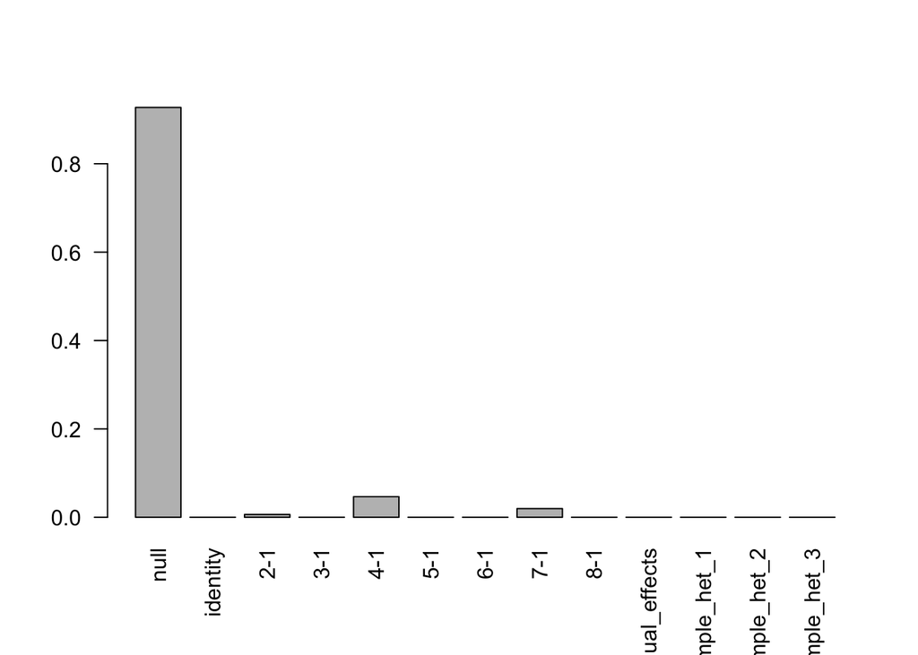

```r
barplot(get_estimated_pi(mashcontrast.model),las = 2)
```

# Comparing discover result with $\hat{\delta}_{j} \sim N_{7}(0,I)$:

```r
Indep.data = mash_set_data(Bhat = data$Chat%*%t(L))
U.c = cov_canonical(Indep.data)
Indep.model = mash(Indep.data, U.c, algorithm.version = 'R')
```

```
 - Computing 10000 x 169 likelihood matrix.
 - Likelihood calculations took 0.73 seconds.
 - Fitting model with 169 mixture components.
 - Model fitting took 1.65 seconds.
 - Computing posterior matrices.
 - Computation allocated took 0.06 seconds.
```

```r
length(get_significant_results(Indep.model))
```

```
[1] 2818
```

There are more false positives.

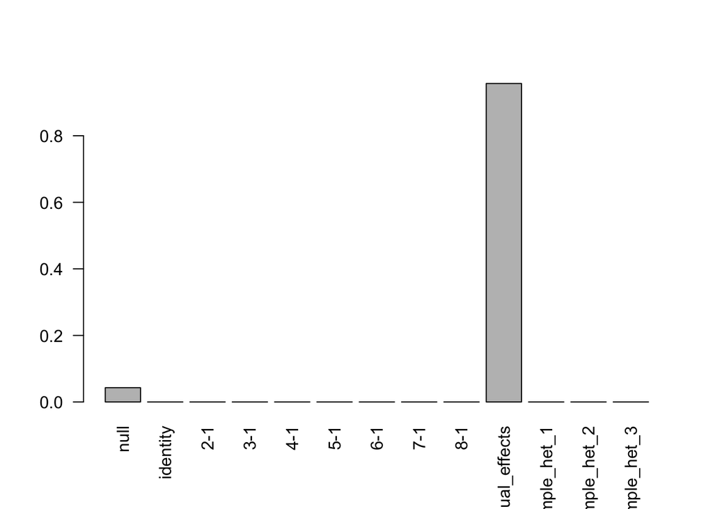

```r
barplot(get_estimated_pi(Indep.model),las = 2)
```

# Comparing discover result with $\hat{z} \sim N_{7}(0,I)$:

In this case, the observed deviations are truly independent.

```r
# simulate true independent delta
D = matrix(0, nrow=10000, ncol = 7)
Shat = matrix(1, nrow=10000, ncol = 7)
set.seed(1)
E = matrix(rnorm(length(Shat), mean=0, sd=Shat), nrow=10000, ncol = 7)
Dhat = D + E
row_ids = paste0("sample_", 1:nrow(D))
col_ids = paste0("condition_", 1:ncol(D))
rownames(D) = row_ids
colnames(D) = col_ids
rownames(Dhat) = row_ids
colnames(Dhat) = col_ids
rownames(Shat) = row_ids
colnames(Shat) = col_ids
```

```r
mash_delta = mash_set_data(Bhat = Dhat, Shat = Shat)
U.c = cov_canonical(mash_delta)
mash_delta_model = mash(mash_delta, U.c, algorithm.version = 'R')
```

```
 - Computing 10000 x 169 likelihood matrix.
 - Likelihood calculations took 0.70 seconds.
 - Fitting model with 169 mixture components.
 - Model fitting took 1.75 seconds.
 - Computing posterior matrices.
 - Computation allocated took 0.03 seconds.
```

```r
length(get_significant_results(mash_delta_model))
```

```
[1] 0
```

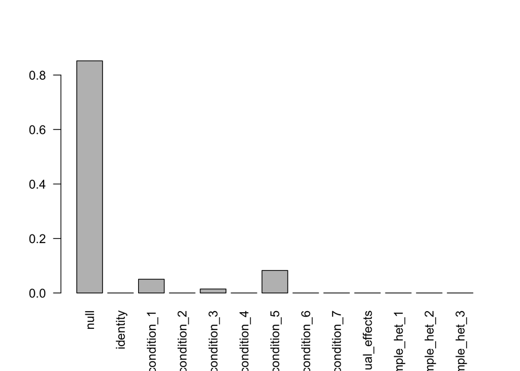

```r
barplot(get_estimated_pi(mash_delta_model),las = 2)
```

From the above comparisons, we show that the wrong assumption $\hat{\delta}\sim N_{7}(0,I)$ produces many more false positives.